[figure not shown]

Métodos de Predictivos (Clasificación o Aprendizaje-Supervisado)

# Índices de Calidad del Modelo y Funciones Auxiliares

**Se necesita cargar las siguientes librerías**

```r
library(tidyverse)
library(glue)
library(scales)
```

**Muestra la distribución de la variable a predecir**

```r
equilibrio.variable.predecir<-function(datos,variable.predecir,ylab="Cantidad de individuos",xlab = "",
                                       main=paste("Distribución de la variable",variable.predecir),
                                       col = NA) {
  gg_color <- function (n) {
     hues <- seq(15, 375, length = n + 1)
     hcl(h = hues, l = 65, c = 100)[1:n]
  }
  if(missing(variable.predecir) | !(variable.predecir %in% colnames(datos))){
    stop("variable.predecir tiene que ser ingresada y ser un nombre de columna", call. = FALSE )
  }
  if(is.character(datos[,variable.predecir]) | is.factor(datos[,variable.predecir])){
    if(length(col) == 0 || is.na(col)){
      col <- gg_color(length(unique(datos[,variable.predecir])))
    }else{
      col <- rep(col,length(unique(datos[,variable.predecir])))
    }
    ggplot(data = datos, mapping = aes_string(x = variable.predecir, fill = variable.predecir)) +
      geom_bar() +
      scale_fill_manual(values = col, name = variable.predecir) +
      labs(x = xlab, y = ylab, title = main) +
      theme_minimal() +
      theme(legend.position = "bottom")
  }else{
    stop("La variable a predecir tienen que ser de tipo factor o character", call. = FALSE )
  }
}
```

**Muestra la distribución de una variable numérica según la variable a predecir**

```r
poder.predictivo.numerica<-function(datos,variable.predecir,variable.comparar,ylab="",xlab="",
                                    main=paste("Densidad de la variable",variable.comparar,'según',variable.predecir),
                                    col=NA){
  gg_color <- function (n) {
     hues <- seq(15, 375, length = n + 1)
     hcl(h = hues, l = 65, c = 100)[1:n]
  }
  if(missing(variable.predecir) | !(variable.predecir %in% colnames(datos))){
    stop("variable.predecir tiene que ser ingresada y ser un nombre de columna", call. = FALSE )
  }
  if(missing(variable.comparar) | !(variable.comparar %in% colnames(datos)) | !is.numeric(datos[,variable.comparar])){
    stop("variable.comparar tiene que ser ingresada y ser un nombre de columna numérica", call. = FALSE )
  }

  if(is.character(datos[,variable.predecir]) | is.factor(datos[,variable.predecir])){
    if(length(col) == 0 || is.na(col)){
      col <- gg_color(length(unique(datos[,variable.predecir])))
    }else{
      col <- rep(col,length(unique(datos[,variable.predecir])))
    }

    ggplot(data = datos, aes_string(variable.comparar, fill = variable.predecir)) +
      geom_density(alpha = .7, color = NA) +
      scale_fill_manual(values = col) +
      labs(title = main , y = ylab, x = xlab ,fill = variable.predecir) +
      theme_minimal() +
      theme(legend.position = 'bottom',
            legend.title = element_blank(),
            text = element_text(size = 15))

  }else{
    stop("La variable a predecir tienen que ser de tipo factor o character", call. = FALSE )
  }
}
```

**Muestra la distribución de una variable categórica según la variable a predecir**

```r
poder.predictivo.categorica<-function(datos,variable.predecir,variable.comparar,ylab="",xlab="",
                                      main=paste("Densidad de la variable",variable.comparar,'según',variable.predecir),
                                      col=NA){
  gg_color <- function (n) {
     hues <- seq(15, 375, length = n + 1)
     hcl(h = hues, l = 65, c = 100)[1:n]
  }
  if(missing(variable.predecir) | !(variable.predecir %in% colnames(datos))){
    stop("variable.predecir tiene que ser ingresada y ser un nombre de columna", call. = FALSE )
  }
  if(missing(variable.comparar) | !(variable.comparar %in% colnames(datos)) |
     !(is.factor(datos[,variable.comparar]) | is.character(datos[,variable.comparar])) ){
    stop("variable.comparar tiene que ser ingresada y ser un nombre de columna categórica", call. = FALSE )
  }

  if(is.character(datos[,variable.predecir]) | is.factor(datos[,variable.predecir])){
    if(length(col) == 0 || is.na(col)){
      col <- gg_color(length(unique(datos[,variable.predecir])))
    }else{
      col <- rep(col,length(unique(datos[,variable.predecir])))
    }

    datos2 <- datos %>%
      dplyr::group_by_(variable.comparar, variable.predecir) %>%
      dplyr::summarise(count = n())

    if(variable.comparar != variable.predecir){
      datos2 <-   datos2 %>% dplyr::group_by_(variable.comparar)
    }
    datos2 <- datos2 %>% dplyr::mutate(prop = round(count/sum(count),4))

    ggplot(data = datos2, mapping = aes_string(x = variable.comparar, y = "prop", fill = variable.predecir)) +
      geom_col(position = "fill") +
      geom_text(aes(label = glue("{percent(prop)} ({count})")), position = position_stack(vjust = .5), color = "white") +
      scale_y_continuous(label = percent) +
      labs(y =  xlab, x  = ylab, title = main) +
      scale_fill_manual(values = col, name = variable.predecir) +
      theme(legend.position = "bottom")+
      coord_flip()

  }else{
    stop("La variable a predecir tienen que ser de tipo factor o character", call. = FALSE )
  }
}
```

**Índices para matrices NxN**

```r
indices.general <- function(MC) {
  precision.global <- sum(diag(MC))/sum(MC)
  error.global <- 1 - precision.global
  precision.categoria <- diag(MC)/rowSums(MC)
  res <- list(matriz.confusion = MC, precision.global = precision.global, error.global = error.global,
              precision.categoria = precision.categoria)
  names(res) <- c("Matriz de Confusión", "Precisión Global", "Error Global",
                  "Precisión por categoría")
  return(res)
}
```

# El método de Bayes

## Ejemplo Iris

```r
setwd("~/Datos(CSV)/")
datos<-read.csv("iris.csv",sep = ";",dec='.',header=T)
datos
```

| s.largo | s.ancho | p.largo | p.ancho | tipo |
| --- | --- | --- | --- | --- |
| 5.1 | 3.5 | 1.4 | 0.2 | setosa |
| 4.9 | 3.0 | 1.4 | 0.2 | setosa |
| 4.7 | 3.2 | 1.3 | 0.2 | setosa |
| 4.6 | 3.1 | 1.5 | 0.2 | setosa |
| 5.0 | 3.6 | 1.4 | 0.2 | setosa |
| 5.4 | 3.9 | 1.7 | 0.4 | setosa |
| 4.6 | 3.4 | 1.4 | 0.3 | setosa |
| 5.0 | 3.4 | 1.5 | 0.2 | setosa |
| 4.4 | 2.9 | 1.4 | 0.2 | setosa |
| 4.9 | 3.1 | 1.5 | 0.1 | setosa |

[output cut: 140 more lines]

```r
str(datos)
```

```
'data.frame':   150 obs. of  5 variables:
 $ s.largo: num  5.1 4.9 4.7 4.6 5 5.4 4.6 5 4.4 4.9 ...
 $ s.ancho: num  3.5 3 3.2 3.1 3.6 3.9 3.4 3.4 2.9 3.1 ...
 $ p.largo: num  1.4 1.4 1.3 1.5 1.4 1.7 1.4 1.5 1.4 1.5 ...
 $ p.ancho: num  0.2 0.2 0.2 0.2 0.2 0.4 0.3 0.2 0.2 0.1 ...
 $ tipo   : Factor w/ 3 levels "setosa","versicolor",..: 1 1 1 1 1 1 1 1 1 1 ...
```

### Distribución de las categorías

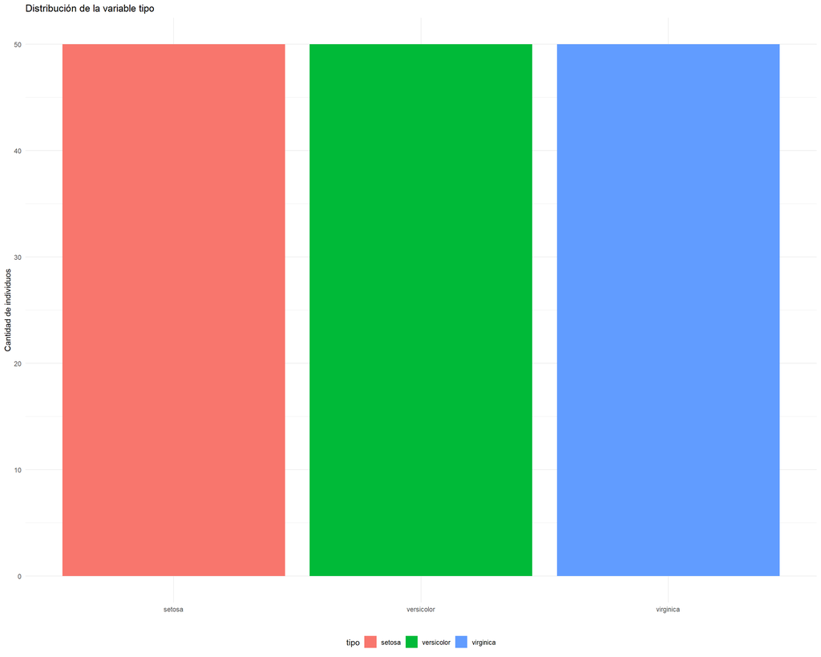

```r
equilibrio.variable.predecir(datos, "tipo")
```

### Predicción

Vamos a generar al azar una tabla de testing de tamaño 50 y una tabla de aprendizaje de tamaño 100.

```r
muestra <- sample(1:nrow(datos), 50)
ttesting <- datos[muestra,]
taprendizaje <- datos[-muestra,]
```

### Paquete e1071

**Se cargan las librerías**

```r
library(e1071)
```

**Se genera el modelo**

```r
# Genera el modelo con parámetros por defecto, no hay nada que calibrar
modelo <- naiveBayes(tipo~., data = taprendizaje)
modelo
```

```
Naive Bayes Classifier for Discrete Predictors

Call:
naiveBayes.default(x = X, y = Y, laplace = laplace)

A-priori probabilities:
Y
    setosa versicolor  virginica
      0.35       0.31       0.34

Conditional probabilities:
            s.largo
Y                [,1]      [,2]
  setosa     4.960000 0.3516348
  versicolor 5.887097 0.5475655
  virginica  6.635294 0.6237144

            s.ancho
Y                [,1]      [,2]
  setosa     3.391429 0.3567595
  versicolor 2.719355 0.3400190
  virginica  2.958824 0.3163405

            p.largo
Y                [,1]      [,2]
  setosa     1.460000 0.1594107
  versicolor 4.203226 0.4922627
  virginica  5.550000 0.5165445

            p.ancho
Y                 [,1]      [,2]
  setosa     0.2428571 0.1170362
  versicolor 1.3096774 0.2055154
  virginica  2.0117647 0.2614235
```

**Se genera la predicción**

```r
prediccion <- predict(modelo, ttesting[,-5])
prediccion
```

```
 [1] virginica  versicolor setosa     virginica  virginica  virginica
 [7] versicolor versicolor versicolor setosa     versicolor setosa
[13] versicolor versicolor virginica  versicolor virginica  virginica
[19] versicolor setosa     virginica  virginica  virginica  setosa
[25] virginica  setosa     virginica  setosa     virginica  versicolor
[31] versicolor virginica  setosa     setosa     setosa     versicolor
[37] versicolor setosa     versicolor versicolor virginica  virginica
[43] setosa     versicolor setosa     setosa     versicolor versicolor
[49] versicolor setosa
Levels: setosa versicolor virginica
```

**Se genera la matriz de confusión**

```r
MC <- table(ttesting$tipo, prediccion)
MC
```

```
            prediccion
             setosa versicolor virginica
  setosa         15          0         0
  versicolor      0         17         2
  virginica       0          2        14
```

**Índices de calidad de la predicción**

```r
indices <- indices.general(MC)
indices
```

```
$`Matriz de Confusión`
            prediccion
             setosa versicolor virginica
  setosa         15          0         0
  versicolor      0         17         2
  virginica       0          2        14

$`Precisión Global`
[1] 0.92

$`Error Global`
[1] 0.08

$`Precisión por categoría`
    setosa versicolor  virginica
 1.0000000  0.8947368  0.8750000
```

### Paquete trainR

**Se cargan las librerías**

```r
library(trainR)
```

**Se genera el modelo**

```r
# Genera el modelo con parámetros por defecto, no hay nada que calibrar
modelo <- train.bayes(tipo~., data = taprendizaje)
modelo
```

```
Naive Bayes Classifier for Discrete Predictors

Call:
naiveBayes.default(x = X, y = Y, laplace = laplace)

A-priori probabilities:
Y
    setosa versicolor  virginica
      0.35       0.31       0.34

Conditional probabilities:
            s.largo
Y                [,1]      [,2]
  setosa     4.960000 0.3516348
  versicolor 5.887097 0.5475655
  virginica  6.635294 0.6237144

            s.ancho
Y                [,1]      [,2]
  setosa     3.391429 0.3567595
  versicolor 2.719355 0.3400190
  virginica  2.958824 0.3163405

            p.largo
Y                [,1]      [,2]
  setosa     1.460000 0.1594107
  versicolor 4.203226 0.4922627
  virginica  5.550000 0.5165445

            p.ancho
Y                 [,1]      [,2]
  setosa     0.2428571 0.1170362
  versicolor 1.3096774 0.2055154
  virginica  2.0117647 0.2614235
```

**Se genera la predicción**

```r
prediccion <- predict(modelo, ttesting)
prediccion
```

```
 [1] virginica  versicolor setosa     virginica  virginica  virginica
 [7] versicolor versicolor versicolor setosa     versicolor setosa
[13] versicolor versicolor virginica  versicolor virginica  virginica
[19] versicolor setosa     virginica  virginica  virginica  setosa
[25] virginica  setosa     virginica  setosa     virginica  versicolor
[31] versicolor virginica  setosa     setosa     setosa     versicolor
[37] versicolor setosa     versicolor versicolor virginica  virginica
[43] setosa     versicolor setosa     setosa     versicolor versicolor
[49] versicolor setosa
Levels: setosa versicolor virginica
```

**Se genera la matriz de confusión**

```r
MC <- confusion.matrix(ttesting, prediccion)
MC
```

```
            prediction
real         setosa versicolor virginica
  setosa         15          0         0
  versicolor      0         17         2
  virginica       0          2        14
```

**Índices de calidad de la predicción**

```r
indices <- general.indexes(mc = MC)
indices
```

```
Confusion Matrix:
            prediction
real         setosa versicolor virginica
  setosa         15          0         0
  versicolor      0         17         2
  virginica       0          2        14

Overall Accuracy: 0.9200
Overall Error:    0.0800

Category Accuracy:

       setosa   versicolor    virginica
     1.000000     0.894737     0.875000
```

**Podemos omitir crear la matriz de confusión**

```r
indices <- general.indexes(ttesting, prediccion)
indices
```

```
Confusion Matrix:
            prediction
real         setosa versicolor virginica
  setosa         15          0         0
  versicolor      0         17         2
  virginica       0          2        14

Overall Accuracy: 0.9200
Overall Error:    0.0800

Category Accuracy:

       setosa   versicolor    virginica
     1.000000     0.894737     0.875000
```

### Selección de Variables

Utilizando los datos que previamente cargamos

```r
datos
```

| s.largo | s.ancho | p.largo | p.ancho | tipo |
| --- | --- | --- | --- | --- |
| 5.1 | 3.5 | 1.4 | 0.2 | setosa |
| 4.9 | 3.0 | 1.4 | 0.2 | setosa |
| 4.7 | 3.2 | 1.3 | 0.2 | setosa |
| 4.6 | 3.1 | 1.5 | 0.2 | setosa |
| 5.0 | 3.6 | 1.4 | 0.2 | setosa |
| 5.4 | 3.9 | 1.7 | 0.4 | setosa |
| 4.6 | 3.4 | 1.4 | 0.3 | setosa |
| 5.0 | 3.4 | 1.5 | 0.2 | setosa |
| 4.4 | 2.9 | 1.4 | 0.2 | setosa |
| 4.9 | 3.1 | 1.5 | 0.1 | setosa |

[output cut: 140 more lines]

Podemos visualizar la distribución de las variables numéricas según la variable a predecir.

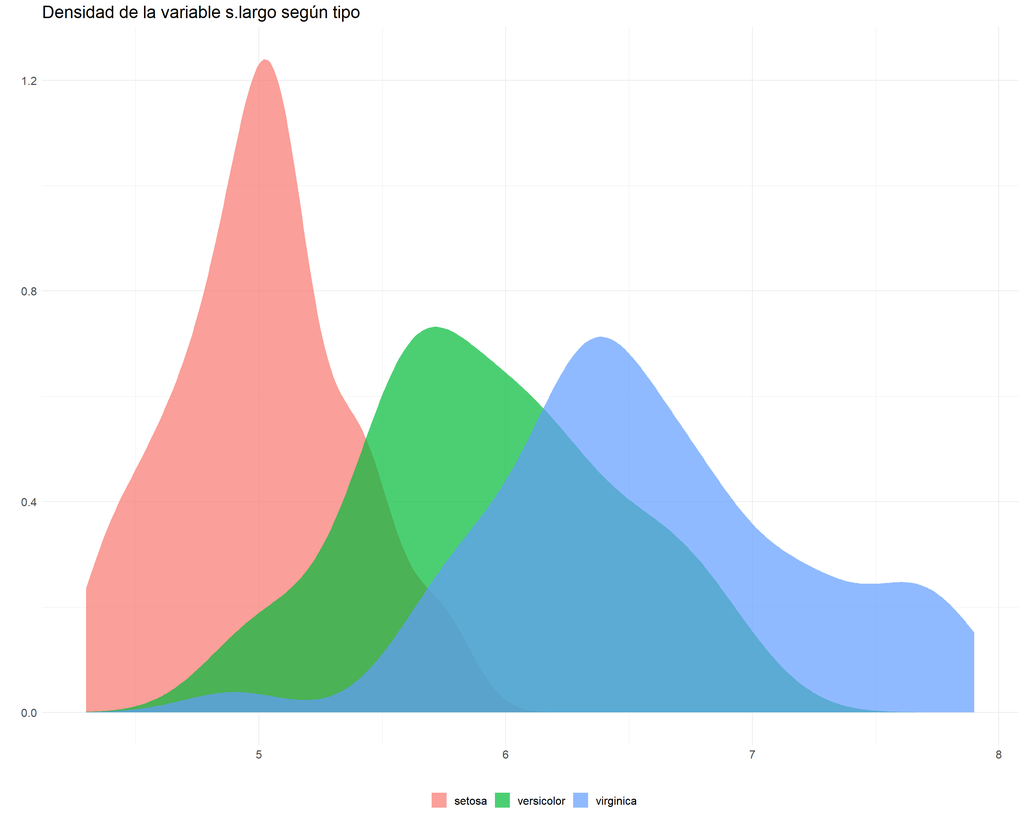

```r
poder.predictivo.numerica(datos, "tipo","s.largo")
```

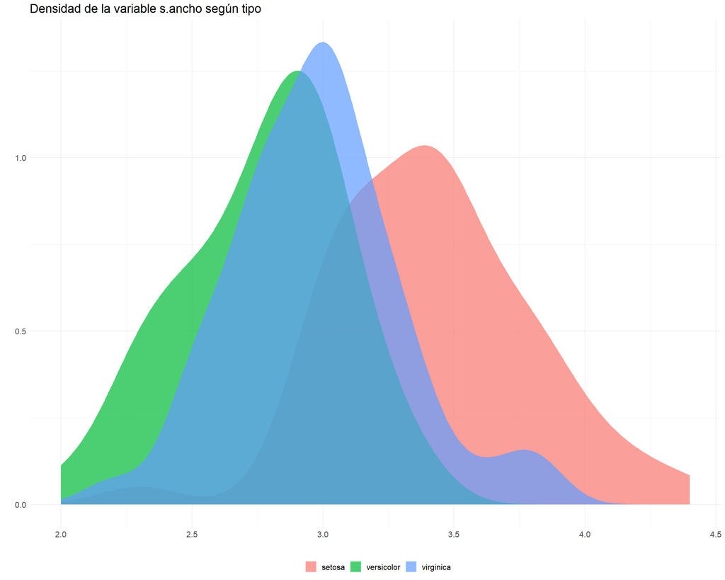

```r
poder.predictivo.numerica(datos, "tipo","s.ancho")
```

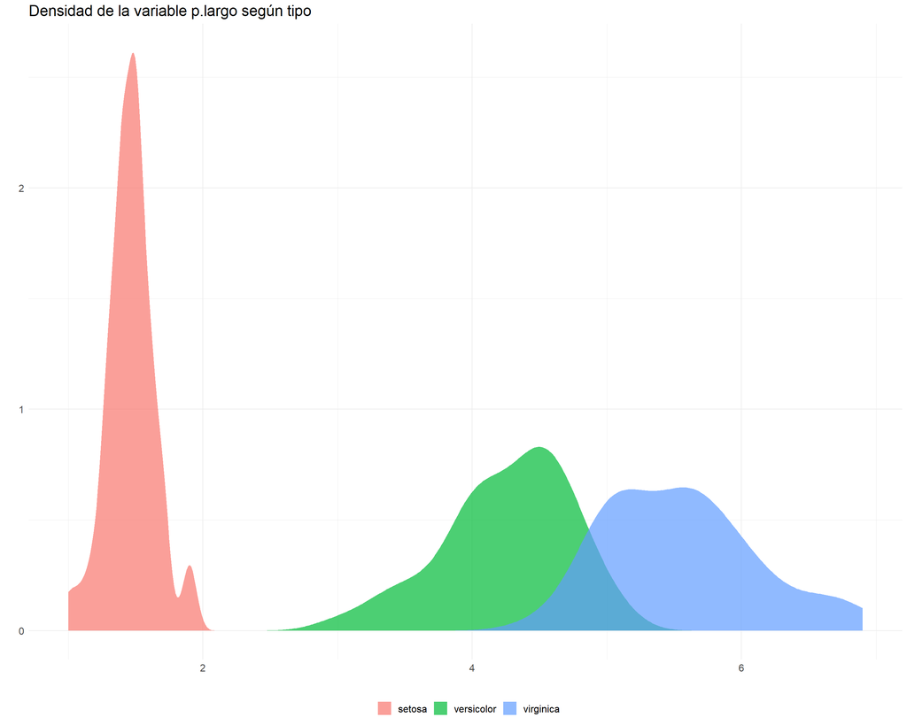

```r
poder.predictivo.numerica(datos, "tipo","p.largo")
```

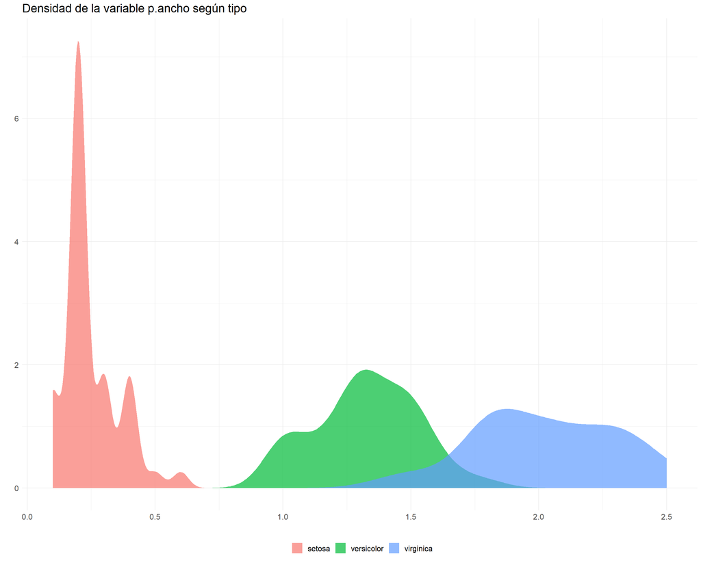

```r
poder.predictivo.numerica(datos, "tipo","p.ancho")
```

### Predicción con selección de variables.

Utilizando los mismo datos para prueba (`ttesting`) y aprendizaje (`taprendizaje`) que creamos anteriormente.

```r
ttesting
```

|  | s.largo | s.ancho | p.largo | p.ancho | tipo |
| --- | --- | --- | --- | --- | --- |
| 148 | 6.5 | 3.0 | 5.2 | 2.0 | virginica |
| 96 | 5.7 | 3.0 | 4.2 | 1.2 | versicolor |
| 4 | 4.6 | 3.1 | 1.5 | 0.2 | setosa |
| 150 | 5.9 | 3.0 | 5.1 | 1.8 | virginica |
| 78 | 6.7 | 3.0 | 5.0 | 1.7 | versicolor |
| 104 | 6.3 | 2.9 | 5.6 | 1.8 | virginica |
| 86 | 6.0 | 3.4 | 4.5 | 1.6 | versicolor |
| 68 | 5.8 | 2.7 | 4.1 | 1.0 | versicolor |
| 92 | 6.1 | 3.0 | 4.6 | 1.4 | versicolor |
| 42 | 4.5 | 2.3 | 1.3 | 0.3 | setosa |

[output cut: 40 more lines]

```r
taprendizaje
```

|  | s.largo | s.ancho | p.largo | p.ancho | tipo |
| --- | --- | --- | --- | --- | --- |
| 1 | 5.1 | 3.5 | 1.4 | 0.2 | setosa |
| 2 | 4.9 | 3.0 | 1.4 | 0.2 | setosa |
| 3 | 4.7 | 3.2 | 1.3 | 0.2 | setosa |
| 6 | 5.4 | 3.9 | 1.7 | 0.4 | setosa |
| 7 | 4.6 | 3.4 | 1.4 | 0.3 | setosa |
| 9 | 4.4 | 2.9 | 1.4 | 0.2 | setosa |
| 10 | 4.9 | 3.1 | 1.5 | 0.1 | setosa |
| 11 | 5.4 | 3.7 | 1.5 | 0.2 | setosa |
| 12 | 4.8 | 3.4 | 1.6 | 0.2 | setosa |
| 13 | 4.8 | 3.0 | 1.4 | 0.1 | setosa |

[output cut: 90 more lines]

### Paquete e1071

**Se cargan las librerías**

```r
library(e1071)
```

**Se genera el modelo**

```r
# Genera el modelo con parámetros por defecto
modelo <- naiveBayes(tipo~p.largo+p.ancho, data = taprendizaje)
modelo
```

```
Naive Bayes Classifier for Discrete Predictors

Call:
naiveBayes.default(x = X, y = Y, laplace = laplace)

A-priori probabilities:
Y
    setosa versicolor  virginica
      0.35       0.31       0.34

Conditional probabilities:
            p.largo
Y                [,1]      [,2]
  setosa     1.460000 0.1594107
  versicolor 4.203226 0.4922627
  virginica  5.550000 0.5165445

            p.ancho
Y                 [,1]      [,2]
  setosa     0.2428571 0.1170362
  versicolor 1.3096774 0.2055154
  virginica  2.0117647 0.2614235
```

**Se genera la predicción**

```r
# Type="class" hace que el modelo prediga clases y no probabilidades
prediccion <- predict(modelo, ttesting[,-5])
prediccion
```

```
 [1] virginica  versicolor setosa     virginica  virginica  virginica
 [7] versicolor versicolor versicolor setosa     versicolor setosa
[13] versicolor versicolor virginica  versicolor virginica  virginica
[19] versicolor setosa     virginica  virginica  virginica  setosa
[25] virginica  setosa     virginica  setosa     versicolor versicolor
[31] versicolor virginica  setosa     setosa     setosa     versicolor
[37] versicolor setosa     versicolor versicolor virginica  virginica
[43] setosa     versicolor setosa     setosa     versicolor virginica
[49] versicolor setosa
Levels: setosa versicolor virginica
```

**Se genera la matriz de confusión**

```r
MC <- table(ttesting[,5],prediccion)
MC
```

```
            prediccion
             setosa versicolor virginica
  setosa         15          0         0
  versicolor      0         17         2
  virginica       0          2        14
```

**Índices de calidad de la predicción**

```r
indices <- indices.general(MC)
indices
```

```
$`Matriz de Confusión`
            prediccion
             setosa versicolor virginica
  setosa         15          0         0
  versicolor      0         17         2
  virginica       0          2        14

$`Precisión Global`
[1] 0.92

$`Error Global`
[1] 0.08

$`Precisión por categoría`
    setosa versicolor  virginica
 1.0000000  0.8947368  0.8750000
```

### Paquete trainR

**Se cargan las librerías**

```r
library(trainR)
```

**Se genera el modelo**

```r
modelo <- train.bayes(tipo~p.largo+p.ancho, data = taprendizaje)
modelo
```

```
Naive Bayes Classifier for Discrete Predictors

Call:
naiveBayes.default(x = X, y = Y, laplace = laplace)

A-priori probabilities:
Y
    setosa versicolor  virginica
      0.35       0.31       0.34

Conditional probabilities:
            p.largo
Y                [,1]      [,2]
  setosa     1.460000 0.1594107
  versicolor 4.203226 0.4922627
  virginica  5.550000 0.5165445

            p.ancho
Y                 [,1]      [,2]
  setosa     0.2428571 0.1170362
  versicolor 1.3096774 0.2055154
  virginica  2.0117647 0.2614235
```

**Se genera la predicción**

```r
prediccion <- predict(modelo, ttesting)
prediccion
```

```
 [1] virginica  versicolor setosa     virginica  virginica  virginica
 [7] versicolor versicolor versicolor setosa     versicolor setosa
[13] versicolor versicolor virginica  versicolor virginica  virginica
[19] versicolor setosa     virginica  virginica  virginica  setosa
[25] virginica  setosa     virginica  setosa     versicolor versicolor
[31] versicolor virginica  setosa     setosa     setosa     versicolor
[37] versicolor setosa     versicolor versicolor virginica  virginica
[43] setosa     versicolor setosa     setosa     versicolor virginica
[49] versicolor setosa
Levels: setosa versicolor virginica
```

**Se genera la matriz de confusión**

```r
MC <- confusion.matrix(ttesting, prediccion)
MC
```

```
            prediction
real         setosa versicolor virginica
  setosa         15          0         0
  versicolor      0         17         2
  virginica       0          2        14
```

**Índices de calidad de la predicción**

```r
indices <- general.indexes(mc = MC)
indices
```

```
Confusion Matrix:
            prediction
real         setosa versicolor virginica
  setosa         15          0         0
  versicolor      0         17         2
  virginica       0          2        14

Overall Accuracy: 0.9200
Overall Error:    0.0800

Category Accuracy:

       setosa   versicolor    virginica
     1.000000     0.894737     0.875000
```

**Podemos omitir crear la matriz de confusión**

```r
indices <- general.indexes(ttesting, prediccion)
indices
```

```
Confusion Matrix:
            prediction
real         setosa versicolor virginica
  setosa         15          0         0
  versicolor      0         17         2
  virginica       0          2        14

Overall Accuracy: 0.9200
Overall Error:    0.0800

Category Accuracy:

       setosa   versicolor    virginica
     1.000000     0.894737     0.875000
```

## Ejemplo Scoring

```r
setwd("~/Datos(CSV)/")
datos<-read.csv("MuestraCredito5000V2.csv",sep = ";",header=T)

# Recodifica las variables como categóricas ordinales
datos$IngresoNeto <- factor(datos$IngresoNeto, ordered = TRUE)
datos$CoefCreditoAvaluo <- factor(datos$CoefCreditoAvaluo, ordered = TRUE)
```

```r
datos
```

| MontoCredito | IngresoNeto | CoefCreditoAvaluo | MontoCuota | GradoAcademico | BuenPagador |
| --- | --- | --- | --- | --- | --- |
| 14327 | 1 | 1 | MuyBajo | Bachiller | Si |
| 111404 | 1 | 1 | MuyBajo | Bachiller | Si |
| 21128 | 1 | 1 | MuyBajo | Bachiller | Si |
| 15426 | 2 | 1 | MuyBajo | Bachiller | Si |
| 10351 | 1 | 1 | MuyBajo | Bachiller | Si |
| 27060 | 1 | 1 | MuyBajo | Bachiller | Si |
| 243369 | 1 | 1 | MuyBajo | Bachiller | Si |
| 16300 | 2 | 1 | MuyBajo | Bachiller | Si |
| 18319 | 2 | 1 | MuyBajo | Bachiller | Si |
| 107037 | 2 | 1 | MuyBajo | Bachiller | Si |

[output cut: 4990 more lines]

```r
str(datos)
```

```
'data.frame':   5000 obs. of  6 variables:
 $ MontoCredito     : int  14327 111404 21128 15426 10351 27060 243369 16300 18319 107037 ...
 $ IngresoNeto      : Ord.factor w/ 2 levels "1"<"2": 1 1 1 2 1 1 1 2 2 2 ...
 $ CoefCreditoAvaluo: Ord.factor w/ 12 levels "1"<"2"<"3"<"4"<..: 1 1 1 1 1 1 1 1 1 1 ...
 $ MontoCuota       : Factor w/ 4 levels "Alto","Bajo",..: 4 4 4 4 4 4 4 4 4 4 ...
 $ GradoAcademico   : Factor w/ 2 levels "Bachiller","Licenciatura": 1 1 1 1 1 1 1 1 1 1 ...
 $ BuenPagador      : Factor w/ 2 levels "No","Si": 2 2 2 2 2 2 2 2 2 2 ...
```

### Distribución de las categorías

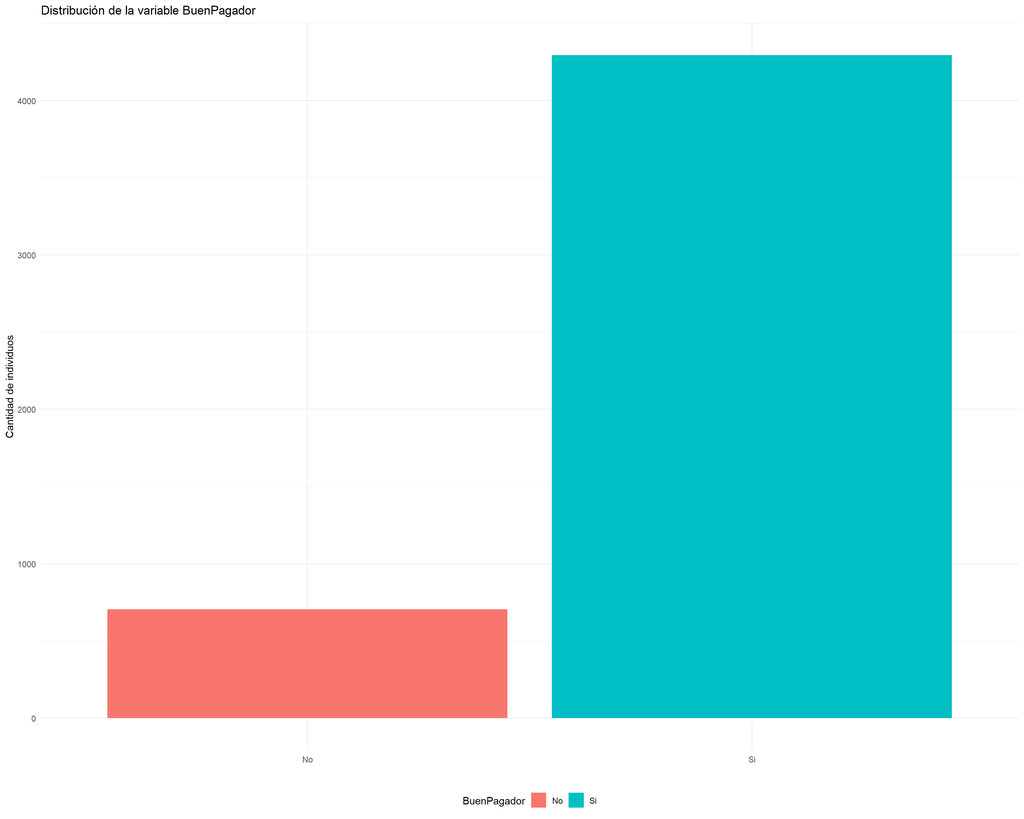

```r
equilibrio.variable.predecir(datos,"BuenPagador")
```

### Predicción

Vamos a generar al azar una tabla de testing con 15% de los datos y una tabla de aprendizaje con 85%

```r
muestra <- sample(1:nrow(datos), floor(nrow(datos)*0.15))
ttesting <- datos[muestra,]
taprendizaje <- datos[-muestra,]
```

### Paquete e1071

**Se cargan las librerías**

```r
library(e1071)
```

**Se genera el modelo**

```r
modelo <- naiveBayes(BuenPagador~.,data = taprendizaje)
modelo
```

```
Naive Bayes Classifier for Discrete Predictors

Call:
naiveBayes.default(x = X, y = Y, laplace = laplace)

A-priori probabilities:
Y
       No        Si
0.1428235 0.8571765

Conditional probabilities:
    MontoCredito
Y        [,1]     [,2]
  No 73257.97 69283.13
  Si 42869.42 52388.63

    IngresoNeto
Y            1         2
  No 0.6523888 0.3476112
  Si 0.4161405 0.5838595

    CoefCreditoAvaluo
Y              1           2           3           4           5
  No 0.039538715 0.000000000 0.000000000 0.079077430 0.029654036
  Si 0.041449355 0.003293988 0.005764480 0.022508921 0.023332418
    CoefCreditoAvaluo
Y              6           7           8           9          10
  No 0.074135091 0.013179572 0.013179572 0.054365733 0.009884679
  Si 0.023606917 0.034312380 0.001372495 0.007136975 0.015920944
    CoefCreditoAvaluo
Y             11          12
  No 0.469522241 0.217462932
  Si 0.276420533 0.544880593

    MontoCuota
Y         Alto      Bajo     Medio   MuyBajo
  No 0.2339374 0.2108731 0.4546952 0.1004942
  Si 0.1100741 0.2854790 0.5479001 0.0565468

    GradoAcademico
Y    Bachiller Licenciatura
  No 0.6062603    0.3937397
  Si 0.5015097    0.4984903
```

**Se genera la predicción**

```r
prediccion <- predict(modelo,ttesting[,-6])
prediccion
```

```
  [1] Si Si Si Si Si Si Si No Si Si Si Si No Si Si Si Si Si Si No Si Si Si
 [24] No Si Si Si Si Si Si Si Si Si Si Si Si Si Si Si Si Si Si No Si Si Si
 [47] Si Si Si Si Si Si Si Si Si Si Si Si Si Si Si Si Si Si Si Si Si Si Si
 [70] Si Si Si Si Si Si Si Si Si Si Si Si Si Si Si No Si No Si Si Si Si Si
 [93] Si Si Si Si Si Si Si Si Si Si Si Si Si Si Si Si Si Si Si Si Si Si Si
[116] Si Si Si Si Si Si Si Si Si Si Si Si Si Si Si Si Si Si Si Si Si Si Si
[139] Si Si Si Si Si Si Si Si Si Si Si No Si Si Si Si Si Si Si Si Si Si Si
[162] Si Si Si Si Si Si No Si Si Si Si Si Si Si Si Si Si Si Si Si Si Si Si
[185] Si Si Si Si Si Si Si Si Si Si Si Si Si Si Si Si Si Si Si Si Si Si Si
[208] Si Si Si Si Si Si Si Si Si Si Si No No Si Si Si Si Si Si Si Si Si Si
[231] Si Si Si Si Si Si Si Si No Si Si Si Si Si Si Si Si Si Si Si Si Si Si
[254] No Si Si Si Si Si Si Si Si Si Si Si Si Si Si Si Si Si Si Si Si Si Si
[277] Si Si Si Si Si Si Si Si Si Si Si Si Si Si Si Si Si Si Si Si Si Si Si
[300] Si Si Si Si Si Si Si Si Si Si Si Si Si Si No Si Si Si Si Si Si Si Si
[323] Si Si Si Si Si Si Si Si Si Si Si Si Si Si Si Si Si Si Si Si Si Si Si
```

[output cut: 19 more lines]

**Se genera la matriz de confusión**

```r
MC <- table(ttesting[,6], prediccion)
MC
```

```
    prediccion
      No  Si
  No  18  80
  Si  20 632
```

**Índices de calidad de la predicción**

```r
indices <- indices.general(MC)
indices
```

```
$`Matriz de Confusión`
    prediccion
      No  Si
  No  18  80
  Si  20 632

$`Precisión Global`
[1] 0.8666667

$`Error Global`
[1] 0.1333333

$`Precisión por categoría`
       No        Si
0.1836735 0.9693252
```

### Paquete trainR

**Se cargan las librerías**

```r
library(trainR)
```

**Se genera el modelo**

```r
modelo <- train.bayes(BuenPagador~.,data = taprendizaje)
modelo
```

```
Naive Bayes Classifier for Discrete Predictors

Call:
naiveBayes.default(x = X, y = Y, laplace = laplace)

A-priori probabilities:
Y
       No        Si
0.1428235 0.8571765

Conditional probabilities:
    MontoCredito
Y        [,1]     [,2]
  No 73257.97 69283.13
  Si 42869.42 52388.63

    IngresoNeto
Y            1         2
  No 0.6523888 0.3476112
  Si 0.4161405 0.5838595

    CoefCreditoAvaluo
Y              1           2           3           4           5
  No 0.039538715 0.000000000 0.000000000 0.079077430 0.029654036
  Si 0.041449355 0.003293988 0.005764480 0.022508921 0.023332418
    CoefCreditoAvaluo
Y              6           7           8           9          10
  No 0.074135091 0.013179572 0.013179572 0.054365733 0.009884679
  Si 0.023606917 0.034312380 0.001372495 0.007136975 0.015920944
    CoefCreditoAvaluo
Y             11          12
  No 0.469522241 0.217462932
  Si 0.276420533 0.544880593

    MontoCuota
Y         Alto      Bajo     Medio   MuyBajo
  No 0.2339374 0.2108731 0.4546952 0.1004942
  Si 0.1100741 0.2854790 0.5479001 0.0565468

    GradoAcademico
Y    Bachiller Licenciatura
  No 0.6062603    0.3937397
  Si 0.5015097    0.4984903
```

**Se genera la predicción**

```r
prediccion <- predict(modelo, ttesting)
prediccion
```

```
  [1] Si Si Si Si Si Si Si No Si Si Si Si No Si Si Si Si Si Si No Si Si Si
 [24] No Si Si Si Si Si Si Si Si Si Si Si Si Si Si Si Si Si Si No Si Si Si
 [47] Si Si Si Si Si Si Si Si Si Si Si Si Si Si Si Si Si Si Si Si Si Si Si
 [70] Si Si Si Si Si Si Si Si Si Si Si Si Si Si Si No Si No Si Si Si Si Si
 [93] Si Si Si Si Si Si Si Si Si Si Si Si Si Si Si Si Si Si Si Si Si Si Si
[116] Si Si Si Si Si Si Si Si Si Si Si Si Si Si Si Si Si Si Si Si Si Si Si
[139] Si Si Si Si Si Si Si Si Si Si Si No Si Si Si Si Si Si Si Si Si Si Si
[162] Si Si Si Si Si Si No Si Si Si Si Si Si Si Si Si Si Si Si Si Si Si Si
[185] Si Si Si Si Si Si Si Si Si Si Si Si Si Si Si Si Si Si Si Si Si Si Si
[208] Si Si Si Si Si Si Si Si Si Si Si No No Si Si Si Si Si Si Si Si Si Si
[231] Si Si Si Si Si Si Si Si No Si Si Si Si Si Si Si Si Si Si Si Si Si Si
[254] No Si Si Si Si Si Si Si Si Si Si Si Si Si Si Si Si Si Si Si Si Si Si
[277] Si Si Si Si Si Si Si Si Si Si Si Si Si Si Si Si Si Si Si Si Si Si Si
[300] Si Si Si Si Si Si Si Si Si Si Si Si Si Si No Si Si Si Si Si Si Si Si
[323] Si Si Si Si Si Si Si Si Si Si Si Si Si Si Si Si Si Si Si Si Si Si Si
```

[output cut: 19 more lines]

**Se genera la matriz de confusión**

```r
MC <- confusion.matrix(ttesting, prediccion)
MC
```

```
    prediction
real  No  Si
  No  18  80
  Si  20 632
```

**Índices de calidad de la predicción**

```r
indices <- general.indexes(mc = MC)
indices
```

```
Confusion Matrix:
    prediction
real  No  Si
  No  18  80
  Si  20 632

Overall Accuracy: 0.8667
Overall Error:    0.1333

Category Accuracy:

           No           Si
     0.183673     0.969325
```

**Podemos omitir crear la matriz de confusión**

```r
indices <- general.indexes(ttesting, prediccion)
indices
```

```
Confusion Matrix:
    prediction
real  No  Si
  No  18  80
  Si  20 632

Overall Accuracy: 0.8667
Overall Error:    0.1333

Category Accuracy:

           No           Si
     0.183673     0.969325
```

### Selección de Variables

Utilizando los datos que previamente cargamos

```r
datos
```

| MontoCredito | IngresoNeto | CoefCreditoAvaluo | MontoCuota | GradoAcademico | BuenPagador |
| --- | --- | --- | --- | --- | --- |
| 14327 | 1 | 1 | MuyBajo | Bachiller | Si |
| 111404 | 1 | 1 | MuyBajo | Bachiller | Si |
| 21128 | 1 | 1 | MuyBajo | Bachiller | Si |
| 15426 | 2 | 1 | MuyBajo | Bachiller | Si |
| 10351 | 1 | 1 | MuyBajo | Bachiller | Si |
| 27060 | 1 | 1 | MuyBajo | Bachiller | Si |
| 243369 | 1 | 1 | MuyBajo | Bachiller | Si |
| 16300 | 2 | 1 | MuyBajo | Bachiller | Si |
| 18319 | 2 | 1 | MuyBajo | Bachiller | Si |
| 107037 | 2 | 1 | MuyBajo | Bachiller | Si |

[output cut: 4990 more lines]

Podemos visualizar la distribución de las variables numéricas y categóricas según la variable a predecir.

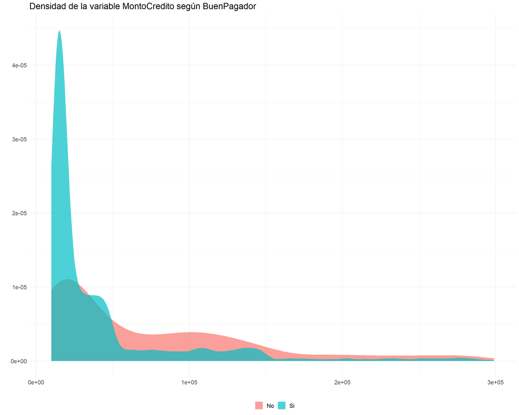

```r
poder.predictivo.numerica(datos, "BuenPagador","MontoCredito")
```

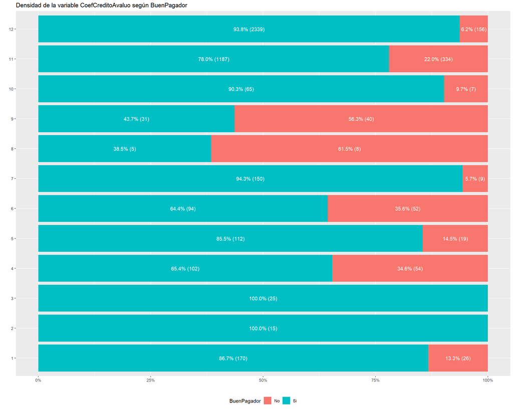

```r
poder.predictivo.categorica(datos,"BuenPagador", "CoefCreditoAvaluo")
```

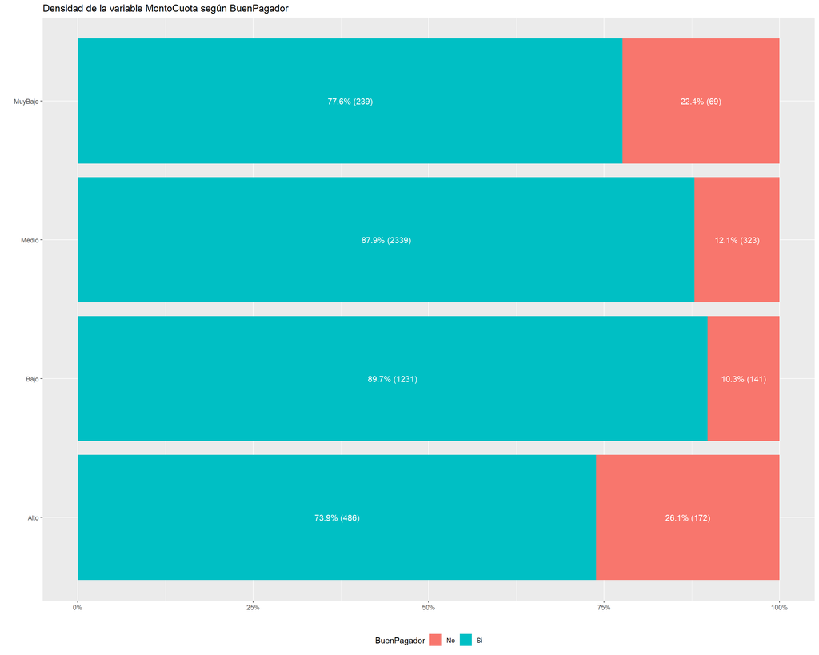

```r
poder.predictivo.categorica(datos,"BuenPagador", "MontoCuota")
```

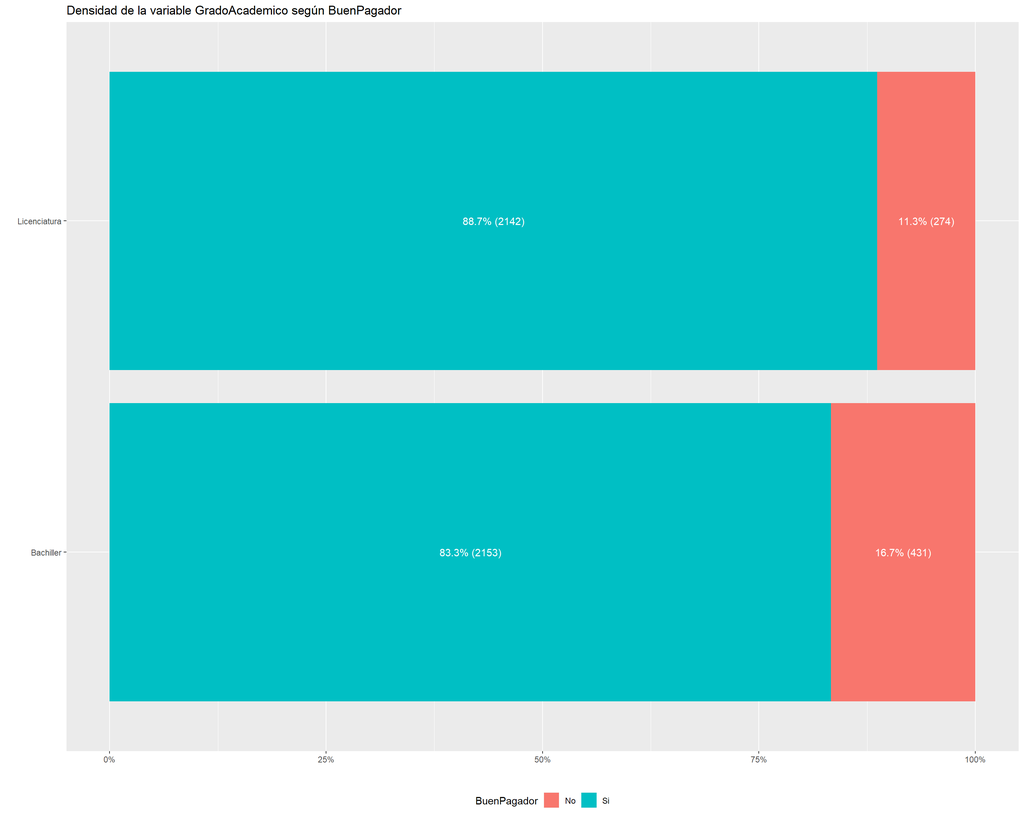

```r
poder.predictivo.categorica(datos,"BuenPagador", "GradoAcademico")
```

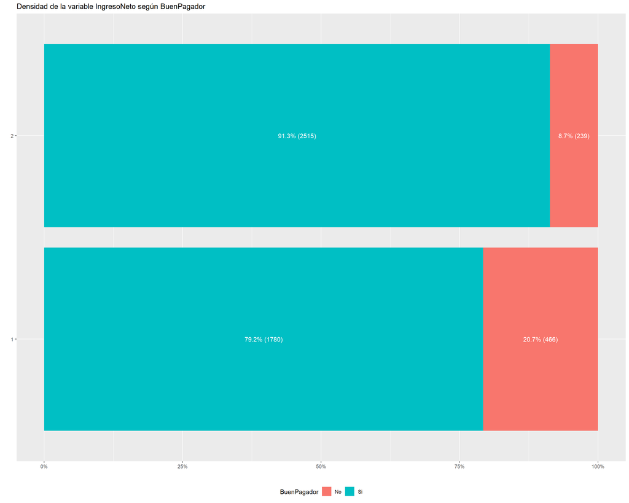

```r
poder.predictivo.categorica(datos,"BuenPagador", "IngresoNeto")
```

### Predicción con selección de variables.

Utilizando los mismo datos para prueba (`ttesting`) y aprendizaje (`taprendizaje`) que creamos anteriormente.

```r
ttesting
```

|  | MontoCredito | IngresoNeto | CoefCreditoAvaluo | MontoCuota | GradoAcademico | BuenPagador |
| --- | --- | --- | --- | --- | --- | --- |
| 3581 | 17920 | 2 | 11 | Medio | Licenciatura | Si |
| 4479 | 50413 | 2 | 7 | Alto | Licenciatura | Si |
| 344 | 11417 | 2 | 6 | Bajo | Licenciatura | Si |
| 1427 | 12481 | 2 | 12 | Medio | Bachiller | Si |
| 2871 | 11115 | 1 | 12 | Bajo | Licenciatura | Si |
| 1397 | 25275 | 2 | 12 | Medio | Bachiller | Si |
| 4701 | 13464 | 1 | 11 | Medio | Bachiller | No |
| 2387 | 283604 | 1 | 12 | MuyBajo | Licenciatura | No |
| 3305 | 19440 | 2 | 12 | Bajo | Bachiller | Si |
| 328 | 49226 | 2 | 12 | Bajo | Bachiller | Si |

[output cut: 740 more lines]

```r
taprendizaje
```

|  | MontoCredito | IngresoNeto | CoefCreditoAvaluo | MontoCuota | GradoAcademico | BuenPagador |
| --- | --- | --- | --- | --- | --- | --- |
| 1 | 14327 | 1 | 1 | MuyBajo | Bachiller | Si |
| 2 | 111404 | 1 | 1 | MuyBajo | Bachiller | Si |
| 3 | 21128 | 1 | 1 | MuyBajo | Bachiller | Si |
| 4 | 15426 | 2 | 1 | MuyBajo | Bachiller | Si |
| 6 | 27060 | 1 | 1 | MuyBajo | Bachiller | Si |
| 7 | 243369 | 1 | 1 | MuyBajo | Bachiller | Si |
| 8 | 16300 | 2 | 1 | MuyBajo | Bachiller | Si |
| 9 | 18319 | 2 | 1 | MuyBajo | Bachiller | Si |
| 10 | 107037 | 2 | 1 | MuyBajo | Bachiller | Si |
| 11 | 10149 | 1 | 1 | MuyBajo | Bachiller | Si |

[output cut: 4240 more lines]

### Paquete e1071

**Se cargan las librerías**

```r
library(e1071)
```

**Se genera el modelo**

```r
modelo <- naiveBayes(BuenPagador~CoefCreditoAvaluo+GradoAcademico+IngresoNeto+MontoCuota,
                     data = taprendizaje)
modelo
```

```
Naive Bayes Classifier for Discrete Predictors

Call:
naiveBayes.default(x = X, y = Y, laplace = laplace)

A-priori probabilities:
Y
       No        Si
0.1428235 0.8571765

Conditional probabilities:
    CoefCreditoAvaluo
Y              1           2           3           4           5
  No 0.039538715 0.000000000 0.000000000 0.079077430 0.029654036
  Si 0.041449355 0.003293988 0.005764480 0.022508921 0.023332418
    CoefCreditoAvaluo
Y              6           7           8           9          10
  No 0.074135091 0.013179572 0.013179572 0.054365733 0.009884679
  Si 0.023606917 0.034312380 0.001372495 0.007136975 0.015920944
    CoefCreditoAvaluo
Y             11          12
  No 0.469522241 0.217462932
  Si 0.276420533 0.544880593

    GradoAcademico
Y    Bachiller Licenciatura
  No 0.6062603    0.3937397
  Si 0.5015097    0.4984903

    IngresoNeto
Y            1         2
  No 0.6523888 0.3476112
  Si 0.4161405 0.5838595

    MontoCuota
Y         Alto      Bajo     Medio   MuyBajo
  No 0.2339374 0.2108731 0.4546952 0.1004942
  Si 0.1100741 0.2854790 0.5479001 0.0565468
```

**Se genera la predicción**

```r
prediccion <- predict(modelo,ttesting[,-6])
prediccion
```

```
  [1] Si Si Si Si Si Si Si Si Si Si Si Si Si Si Si Si Si Si Si No Si Si Si
 [24] Si Si Si Si Si Si Si Si Si Si Si Si Si Si Si Si Si Si Si Si Si Si Si
 [47] Si Si Si Si Si Si Si Si Si Si Si Si Si Si Si Si Si Si Si Si Si Si Si
 [70] Si Si Si Si Si Si Si Si Si Si Si Si Si Si Si Si Si No Si Si Si Si Si
 [93] Si Si Si Si Si Si Si Si Si Si Si Si Si Si Si Si Si Si Si Si Si Si Si
[116] Si No Si Si Si Si Si Si Si Si Si Si Si Si Si Si Si Si Si Si Si Si Si
[139] Si Si Si Si Si Si Si Si Si Si Si No No Si Si Si Si Si Si Si No Si No
[162] Si Si Si Si Si No No Si Si Si Si Si Si Si Si Si Si Si Si Si Si Si Si
[185] Si Si Si Si Si Si Si Si Si Si Si Si Si Si Si Si Si No Si Si Si Si Si
[208] Si Si Si Si Si Si Si Si Si Si Si No Si Si Si Si Si Si Si Si Si Si Si
[231] Si Si Si Si Si Si Si Si Si Si Si Si Si Si Si Si Si Si Si Si Si Si Si
[254] Si Si Si Si No Si Si Si Si Si Si Si Si Si Si Si Si Si Si Si Si Si Si
[277] Si Si Si Si Si Si Si Si Si Si Si Si No Si Si Si Si Si Si Si Si Si Si
[300] Si Si Si Si Si Si Si Si Si Si Si Si Si Si Si Si Si Si Si Si Si Si Si
[323] Si Si Si Si Si Si Si Si Si Si Si Si Si Si Si Si Si Si Si Si Si Si Si
```

[output cut: 19 more lines]

**Se genera la matriz de confusión**

```r
MC <- table(ttesting$BuenPagador, prediccion)
MC
```

```
    prediccion
      No  Si
  No  23  75
  Si   6 646
```

**Índices de calidad de la predicción**

```r
indices <- indices.general(MC)
indices
```

```
$`Matriz de Confusión`
    prediccion
      No  Si
  No  23  75
  Si   6 646

$`Precisión Global`
[1] 0.892

$`Error Global`
[1] 0.108

$`Precisión por categoría`
       No        Si
0.2346939 0.9907975
```

### Paquete trainR

**Se cargan las librerías**

```r
library(trainR)
```

**Se genera el modelo**

```r
modelo <- train.bayes(BuenPagador~CoefCreditoAvaluo+GradoAcademico+IngresoNeto+MontoCuota,
                     data = taprendizaje)
modelo
```

```
Naive Bayes Classifier for Discrete Predictors

Call:
naiveBayes.default(x = X, y = Y, laplace = laplace)

A-priori probabilities:
Y
       No        Si
0.1428235 0.8571765

Conditional probabilities:
    CoefCreditoAvaluo
Y              1           2           3           4           5
  No 0.039538715 0.000000000 0.000000000 0.079077430 0.029654036
  Si 0.041449355 0.003293988 0.005764480 0.022508921 0.023332418
    CoefCreditoAvaluo
Y              6           7           8           9          10
  No 0.074135091 0.013179572 0.013179572 0.054365733 0.009884679
  Si 0.023606917 0.034312380 0.001372495 0.007136975 0.015920944
    CoefCreditoAvaluo
Y             11          12
  No 0.469522241 0.217462932
  Si 0.276420533 0.544880593

    GradoAcademico
Y    Bachiller Licenciatura
  No 0.6062603    0.3937397
  Si 0.5015097    0.4984903

    IngresoNeto
Y            1         2
  No 0.6523888 0.3476112
  Si 0.4161405 0.5838595

    MontoCuota
Y         Alto      Bajo     Medio   MuyBajo
  No 0.2339374 0.2108731 0.4546952 0.1004942
  Si 0.1100741 0.2854790 0.5479001 0.0565468
```

**Se genera la predicción**

```r
prediccion <- predict(modelo, ttesting)
prediccion
```

```
  [1] Si Si Si Si Si Si Si Si Si Si Si Si Si Si Si Si Si Si Si No Si Si Si
 [24] Si Si Si Si Si Si Si Si Si Si Si Si Si Si Si Si Si Si Si Si Si Si Si
 [47] Si Si Si Si Si Si Si Si Si Si Si Si Si Si Si Si Si Si Si Si Si Si Si
 [70] Si Si Si Si Si Si Si Si Si Si Si Si Si Si Si Si Si No Si Si Si Si Si
 [93] Si Si Si Si Si Si Si Si Si Si Si Si Si Si Si Si Si Si Si Si Si Si Si
[116] Si No Si Si Si Si Si Si Si Si Si Si Si Si Si Si Si Si Si Si Si Si Si
[139] Si Si Si Si Si Si Si Si Si Si Si No No Si Si Si Si Si Si Si No Si No
[162] Si Si Si Si Si No No Si Si Si Si Si Si Si Si Si Si Si Si Si Si Si Si
[185] Si Si Si Si Si Si Si Si Si Si Si Si Si Si Si Si Si No Si Si Si Si Si
[208] Si Si Si Si Si Si Si Si Si Si Si No Si Si Si Si Si Si Si Si Si Si Si
[231] Si Si Si Si Si Si Si Si Si Si Si Si Si Si Si Si Si Si Si Si Si Si Si
[254] Si Si Si Si No Si Si Si Si Si Si Si Si Si Si Si Si Si Si Si Si Si Si
[277] Si Si Si Si Si Si Si Si Si Si Si Si No Si Si Si Si Si Si Si Si Si Si
[300] Si Si Si Si Si Si Si Si Si Si Si Si Si Si Si Si Si Si Si Si Si Si Si
[323] Si Si Si Si Si Si Si Si Si Si Si Si Si Si Si Si Si Si Si Si Si Si Si
```

[output cut: 19 more lines]

**Se genera la matriz de confusión**

```r
MC <- confusion.matrix(ttesting, prediccion)
MC
```

```
    prediction
real  No  Si
  No  23  75
  Si   6 646
```

**Índices de calidad de la predicción**

```r
indices <- general.indexes(mc = MC)
indices
```

```
Confusion Matrix:
    prediction
real  No  Si
  No  23  75
  Si   6 646

Overall Accuracy: 0.8920
Overall Error:    0.1080

Category Accuracy:

           No           Si
     0.234694     0.990798
```

**Podemos omitir crear la matriz de confusión**

```r
indices <- general.indexes(ttesting, prediccion)
indices
```

```
Confusion Matrix:
    prediction
real  No  Si
  No  23  75
  Si   6 646

Overall Accuracy: 0.8920
Overall Error:    0.1080

Category Accuracy:

           No           Si
     0.234694     0.990798
```